# TO414 Project 3: Spotify

We can also look at the residual plot.

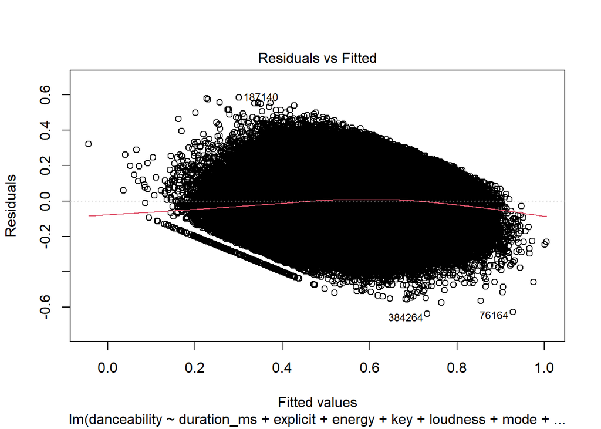

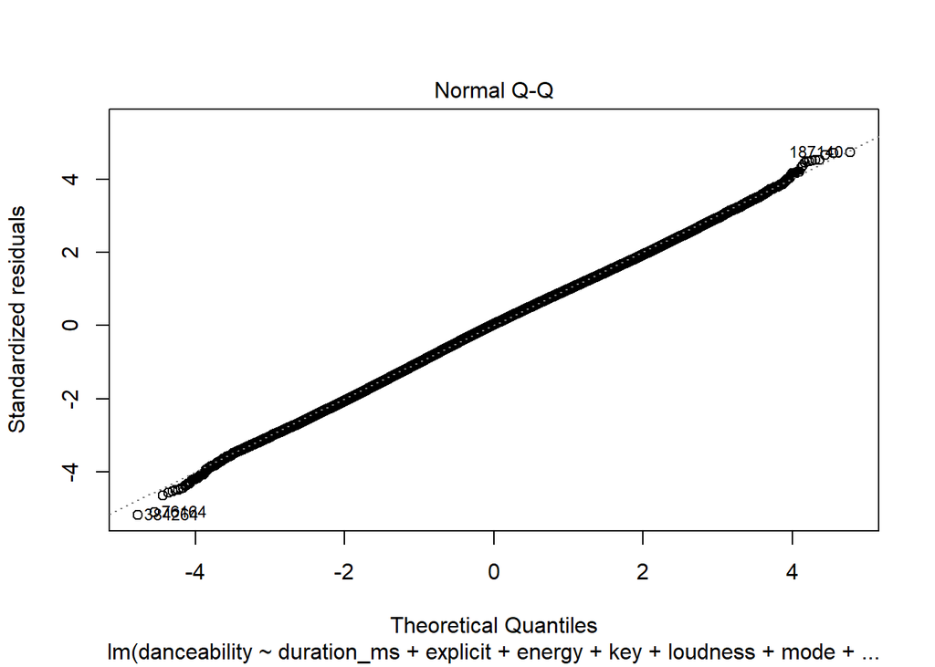

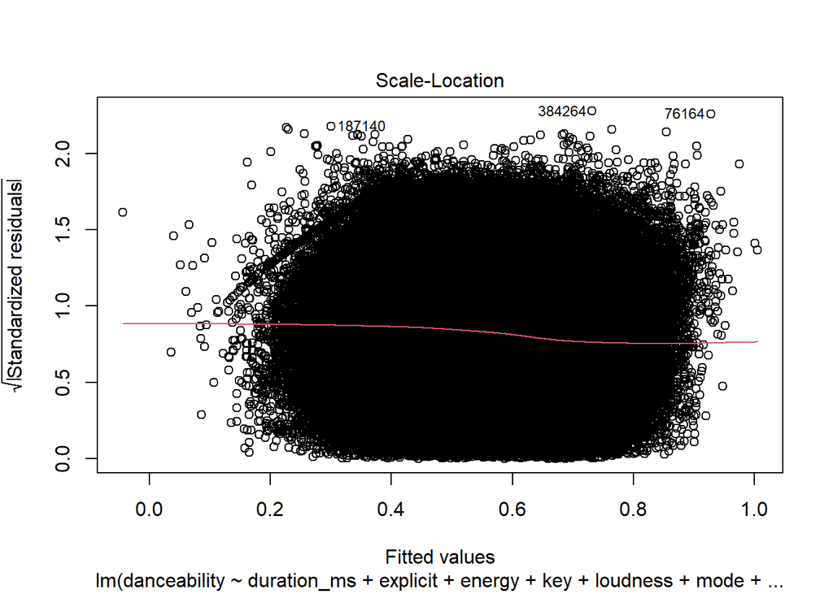

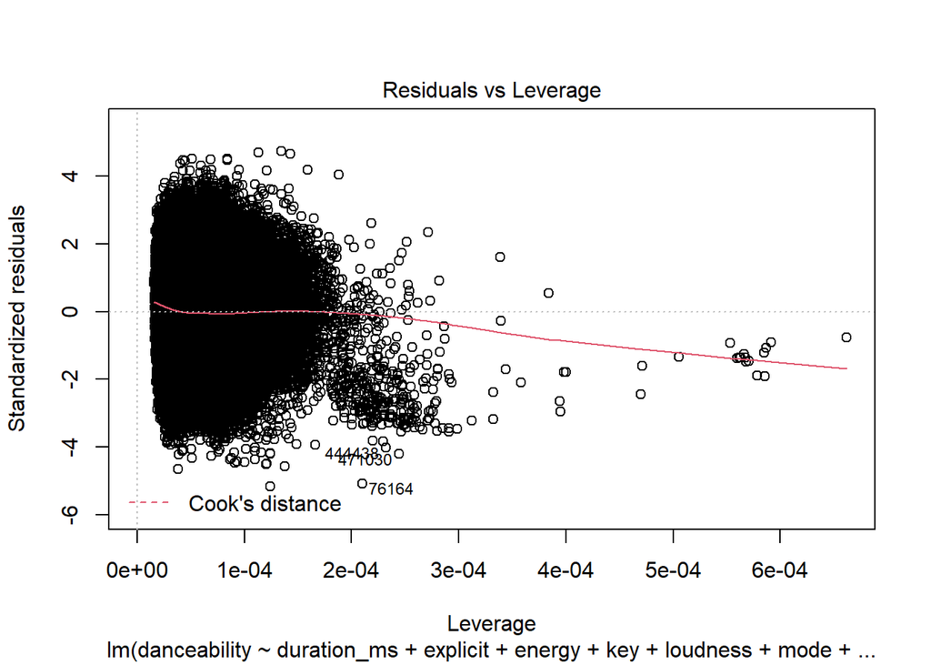

```r
plot(step_dm1) #Data is reasonably scattered, but there appears to be some interactions of nonlinear components
```

**So, how well does `step_dm1` predict danceability score?**

```r
# Apply   `step_dm1` to test set
step_dm1_results <- predict(step_dm1,newdata = audio_test, type="response")

# Calculate errors between danceability predictions and test labels
step_dm1_error <- audio_test_labs - step_dm1_results
step_dm1_test_RMSE <- sqrt(mean(step_dm1_error^2))  # RSME = 0.12
step_dm1_test_r2 <- summary(step_dm1)$adj.r.squared  #R^2 = 0.44
step_dm1_test_MAE <- MAE(step_dm1_results,audio_test_labs) # MAE=0.099
step_dm1_test_MSE <- mean((step_dm1_error)^2) #MSE = 0.015

dm_error_table <- matrix(c(step_dm1_test_MSE,step_dm1_test_MAE,step_dm1_test_RMSE,step_dm1_test_r2),ncol=4,byrow=T)
colnames(dm_error_table) <- c("MSE", "MAE", "RSME", "R-squared")
rownames(dm_error_table) <- c("step_dm1")
dm_error_table <- as.table(dm_error_table)

dm_error_table
```

```
##                 MSE        MAE       RSME  R-squared
## step_dm1 0.01533028 0.09908799 0.12381552 0.44278088
```

The above error metrics describe how well `step_dm1` can fit the available explanatory variables to the `danceability` distribution. We will return to these numbers after making some attempts to improve the model fit.

## Danceability Model Improvements with Nonlinearity and Interactions

If we recall, Spotify included music elements such as musical elements including tempo, rhythm stability, beat strength, and overall regularity. Therefore, we would expect a very high correlation between corresponding available explanatory variables, such as `tempo`. Let’s quantify the correlation between `tempo` and `danceability`. We will work with a slightly reduced data set to simplify visual interpretation.

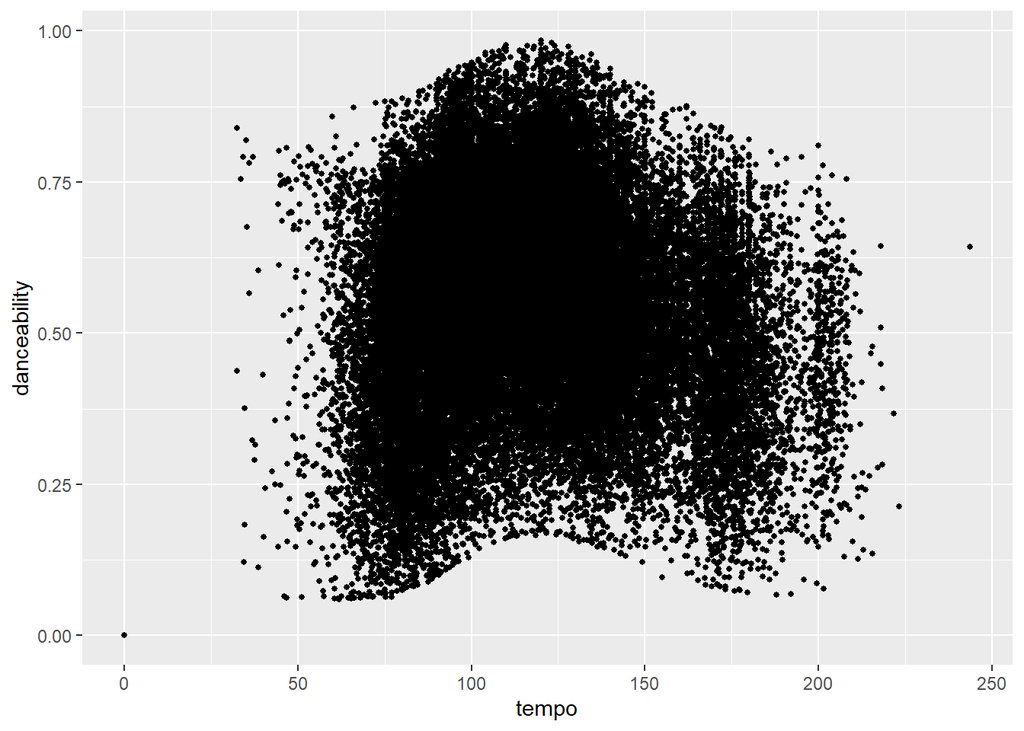

```r
#Randomly take 100,000 rows into shrunken set
audio_train_shrunk_rows <- sample(1:nrow(audio_train),
                              replace = F,
                              size = 50000)
audio_train_shrunk <- audio_train[audio_train_shrunk_rows, ]


#Plot danceability vs tempo
dance_tempo <- ggplot(data=audio_train_shrunk, aes(x=tempo, y=danceability)) + geom_point(size=1)
dance_tempo #negative quadratic shape
```

This chart takes a very interesting appearance, with a clear quadratic interaction (as danceability peaks around medium-tempo). However the data has a large variance. Incorporating a quadratic `tempo` term in the `step_dm1` model improves Adj R^squared by 6.3%.

```r
dm2 <- lm(danceability ~ duration_ms + explicit + energy + key0 + key1 + key2 + key3 + key4 + key5 + key7 + key9 + loudness + mode1 + speechiness + acousticness + instrumentalness + liveness + valence +  I(tempo^2)+ tempo+ time_signature + release_year, data=audio_trainMM)
summary(dm2) #Adj R62 = 0.506
```

```
##
## Call:
## lm(formula = danceability ~ duration_ms + explicit + energy +
##     key0 + key1 + key2 + key3 + key4 + key5 + key7 + key9 + loudness +
##     mode1 + speechiness + acousticness + instrumentalness + liveness +
##     valence + I(tempo^2) + tempo + time_signature + release_year,
##     data = audio_trainMM)
##
## Residuals:
##      Min       1Q   Median       3Q      Max
## -0.65838 -0.07765  0.00296  0.07934  0.64691
##
## Coefficients:
##                    Estimate Std. Error  t value Pr(>|t|)
## (Intercept)      -2.990e+00  1.763e-02 -169.649  < 2e-16 ***
## duration_ms      -9.521e-09  2.087e-09   -4.562 5.06e-06 ***
## explicit          6.121e-02  7.884e-04   77.642  < 2e-16 ***
## energy           -1.875e-01  1.304e-03 -143.798  < 2e-16 ***
## key0             -1.913e-03  5.472e-04   -3.496 0.000473 ***
## key1              6.472e-03  6.710e-04    9.644  < 2e-16 ***
## key2             -1.017e-02  5.678e-04  -17.914  < 2e-16 ***
## key3             -9.162e-03  8.820e-04  -10.388  < 2e-16 ***
## key4             -8.735e-03  6.331e-04  -13.798  < 2e-16 ***
## key5             -3.499e-03  6.099e-04   -5.737 9.64e-09 ***
## key7             -3.847e-03  5.492e-04   -7.004 2.49e-12 ***
## key9             -1.103e-02  5.683e-04  -19.414  < 2e-16 ***
## loudness          5.292e-03  5.267e-05  100.474  < 2e-16 ***
## mode1            -8.070e-03  3.386e-04  -23.836  < 2e-16 ***
## speechiness       2.306e-01  9.839e-04  234.406  < 2e-16 ***
## acousticness     -6.249e-02  6.989e-04  -89.407  < 2e-16 ***
## instrumentalness -1.547e-02  6.539e-04  -23.653  < 2e-16 ***
## liveness         -1.090e-01  8.955e-04 -121.667  < 2e-16 ***
## valence           3.449e-01  7.070e-04  487.893  < 2e-16 ***
## I(tempo^2)       -3.620e-05  1.362e-07 -265.704  < 2e-16 ***
## tempo             8.374e-03  3.462e-05  241.852  < 2e-16 ***
## time_signature    2.081e-02  3.421e-04   60.846  < 2e-16 ***
## release_year      1.521e-03  8.667e-06  175.481  < 2e-16 ***
## ---
## Signif. codes:  0 '***' 0.001 '**' 0.01 '*' 0.05 '.' 0.1 ' ' 1
##
## Residual standard error: 0.1161 on 550782 degrees of freedom
## Multiple R-squared:  0.5061, Adjusted R-squared:  0.5061
## F-statistic: 2.565e+04 on 22 and 550782 DF,  p-value: < 2.2e-16
```

```r
summary(dm2)$adj.r.squared - step_dm1_test_r2 #.063
```

```
## [1] 0.06330755
```

The negative co-efficient estimate for the quadratic tempo term `I(tempo^2)` of -.0000362 with high significance suggests that danceability score is highest for moderate tempos, with the score decreasing as tempo is adjusted very far in either direction. This is logical, since it is difficult to dance along to very slow-paced music or incredibly-charged-up music to which the dancer cannot keep up.

We also investigate some possible interactions between pairings of explanatory variables. Note that many of these graphs are dense with high variation and unclear correlations. This is chiefly due to the great diversity in audio tracks housed by Spotify.

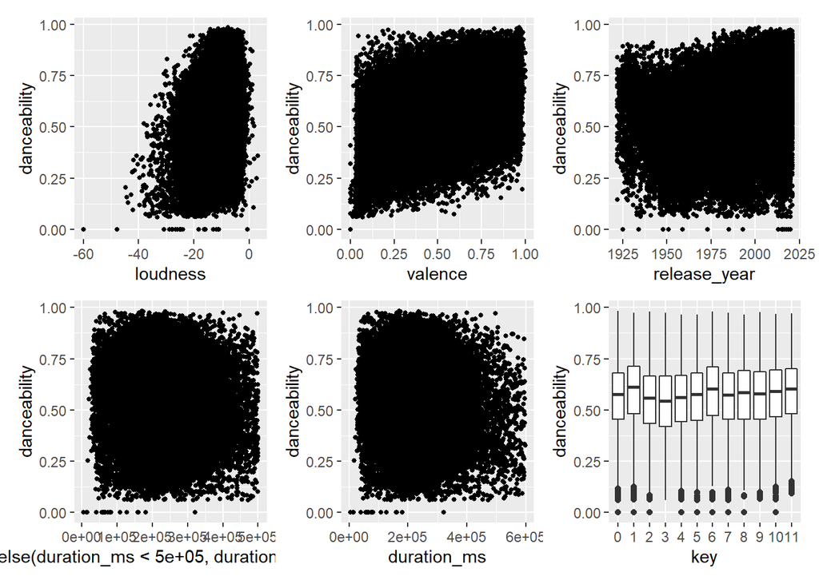

```r
#Check for nonlinearity
gp1<-ggplot(data=audio_train_shrunk, aes(x=loudness, y=danceability)) + geom_point(size=1) #positive correlation
gp2<-ggplot(data=audio_train_shrunk, aes(x=valence, y=danceability)) + geom_point(size=1) #positive correlation
gp3<-ggplot(data=audio_train_shrunk, aes(x=release_year, y=danceability)) + geom_point(size=1) #unclear correlation
gp4<-ggplot(data=audio_train_shrunk, aes(x=ifelse(duration_ms<500000,duration_ms,NA), y=danceability)) + geom_point(size=1) #unclear correlation, slightly negative
gp5<-ggplot(data=audio_train_shrunk, aes(x=duration_ms, y=danceability)) + geom_point(size=1) #unclear correlation, slightly negative
gp6<-ggplot(data=audio_train_shrunk, aes(x=key, y=danceability)) + geom_boxplot() #no trend

gp1 + gp2 + gp3 + gp4 + gp5 + gp6
```

```r
  plot_layout(ncol = 3)
```

[output not shown]

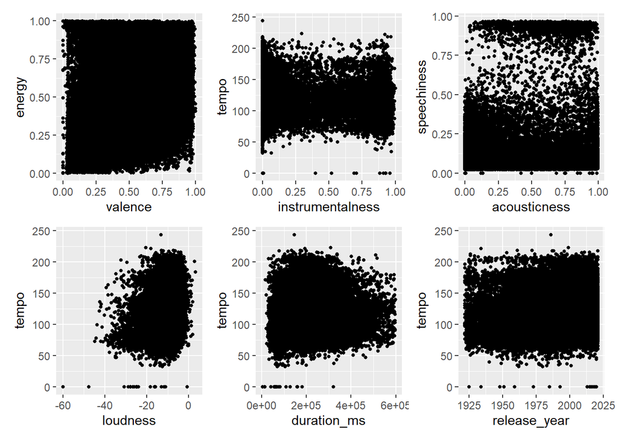

```r
#Check for Interactions
gp7<-ggplot(data=audio_train_shrunk, aes(x=valence, y=energy)) + geom_point(size=1) # no clear trend, slight positive correlation
gp8<-ggplot(data=audio_train_shrunk, aes(x=instrumentalness, y=tempo)) + geom_point(size=1) #greater tempo variance for lower instrumentalness
gp9<-ggplot(data=audio_train_shrunk, aes(x=acousticness, y=speechiness)) + geom_point(size=1) # no clear trend
gp10<-ggplot(data=audio_train_shrunk, aes(x=loudness, y=tempo)) + geom_point(size=1) #positive correlation
gp11<-ggplot(data=audio_train_shrunk, aes(x=duration_ms, y=tempo)) + geom_point(size=1) #positive correlation
gp12<-ggplot(data=audio_train_shrunk, aes(x=release_year, y=tempo)) + geom_point(size=1) #positive correlation

gp7 + gp8 + gp9 + gp10 + gp11 + gp12
```

```r
  plot_layout(ncol = 3)
```

[output not shown]

In the next chunk, we will perform several variations to improve the model correlation. These models are summarized in the table below.

| Model | R-Squared | Incorporation Since Previous |
| --- | --- | --- |
| dm1 | 44.3% | danceability ~ . in audio_train |
| step_dm1 | 44.3% | Removes some insignificant keys |
| dm2 | 50.6% | quadratic effect of tempo |
| dm3 | 51.0% | interactions: energy~valence |
| dm4 | 51.1% | interactions which yield minimal improvement |
| dm5 | 51.2% | quadratic effect of energy |
| dm6 | 52.5% | quadratic effect of release_year |

Here are several model iterations which improve correlation by incorporating further quadratic and interaction terms.

```r
#Adj R^2 to beat: 0.5114 in `dm2`


#energy~valence
dm3 <- lm(danceability ~ duration_ms + explicit + energy + energy*valence + key0 + key1 + key2 + key3 + key4 + key5 + key7 + key9 + loudness + mode1 + speechiness + acousticness + instrumentalness + liveness + valence +  tempo + I(tempo^2) + time_signature + release_year, data=audio_trainMM)
summary(dm3)$adj.r.squared #Adj R^2 = 0.510
```

```
## [1] 0.5106677
```

```r
#loudness*tempo and acousticness*instrumentalness and tempo*instrumentalness and speechiness~explicit and duration_ms*tempo
dm4 <- lm(danceability ~ duration_ms + explicit + explicit*speechiness + energy + energy*valence + key0 + key1 + key2 + key3 + key4 + key5 + key7 + key9 + loudness + loudness*tempo + mode1 + speechiness + acousticness + instrumentalness + acousticness*instrumentalness  + liveness + valence  +  tempo + I(tempo^2) + time_signature + tempo*instrumentalness + release_year, data=audio_trainMM)
summary(dm4)$adj.r.squared #Adj R^2 = 0.511, very limited improvements from these interactions
```

```
## [1] 0.5111197
```

```r
#I(energy^2)
dm5 <- lm(danceability ~ duration_ms + explicit + explicit*speechiness + energy + energy*valence + key0 + key1 + key2 + key3 + key4 + key5 + key7 + key9 + loudness + loudness*tempo + mode1 + speechiness + acousticness + instrumentalness + acousticness*instrumentalness  + liveness + valence + I(energy^2) +  tempo + I(tempo^2) + time_signature + tempo*instrumentalness+ duration_ms*tempo +  release_year, data=audio_trainMM)
summary(dm5)$adj.r.squared #Adj R^2 = 0.512
```

```
## [1] 0.5123301
```

```r
#I(release_year^2)
dm6 <- lm(danceability ~ duration_ms + explicit + explicit*speechiness + energy + energy*valence + key0 + key1 + key2 + key3 + key4 + key5 + key7 + key9 + loudness + loudness*tempo + mode1 + speechiness + acousticness + instrumentalness + acousticness*instrumentalness  + liveness + valence  +  tempo + I(tempo^2) + time_signature +I(energy^2)+ tempo*instrumentalness+ duration_ms*tempo +  I(release_year^2)+  release_year, data=audio_trainMM)
summary(dm6)$adj.r.squared #Adj R^2 = 0.525
```

```
## [1] 0.5250364
```

```r
#summary(dm6)  #Co-eff estimate of I(release_year^2) is 3.4e-05

dm_error_table
```

```
##                 MSE        MAE       RSME  R-squared
## step_dm1 0.01533028 0.09908799 0.12381552 0.44278088
```

The model iterations suggest Spotify considers music more suitable for dancing when it has a moderately-fast tempo and less-suitable for dancing when it has a slow or extremely-fast tempo. Spotify also considers very old and most new music more danceable, while “middle-aged” music (such as from the 60s) may be less-danceable.

### Model Prediction Error Comparison

Let’s compare the prediction error by the models which improved correlation from the previous iteration by at least 1% (taking `step_dm1` as the base reference):

- `step_dm1`
- `dm2`
- `dm6`

```r
# Apply   `dm2` to test set
dm2_results <- predict(dm2,newdata = audio_testMM, type="response")
# Calculate errors for dm2
dm2_error <- audio_test_labs - dm2_results
dm2_test_r2 <- summary(dm2)$adj.r.squared
dm2_test_MSE <- mean((dm2_error)^2)
dm2_test_MAE <- MAE(dm2_results,audio_test_labs)
dm2_test_RMSE <- sqrt(mean(dm2_error^2))


# Apply   `dm6` to test set
dm6_results <- predict(dm6,newdata = audio_testMM, type="response")
# Calculate errors for dm6
dm6_error <- audio_test_labs - dm6_results
dm6_test_r2 <- summary(dm6)$adj.r.squared
dm6_test_MSE <- mean((dm6_error)^2)
dm6_test_MAE <- MAE(dm6_results,audio_test_labs)
dm6_test_RMSE <- sqrt(mean(dm6_error^2))


#Build error table
dm_error_table <- matrix(c(step_dm1_test_r2,step_dm1_test_MSE,step_dm1_test_MAE,step_dm1_test_RMSE,
                           dm2_test_r2,dm2_test_MSE,dm2_test_MAE,dm2_test_RMSE,
                           dm6_test_r2,dm6_test_MSE,dm6_test_MAE,dm6_test_RMSE),
                         ncol=4,byrow=T)
colnames(dm_error_table) <- c("R-squared","MSE", "MAE", "RSME")
rownames(dm_error_table) <- c("step_dm1","dm2","dm6")

dm_error_table <- as.table(dm_error_table)
dm_error_table
```

```
##           R-squared        MSE        MAE       RSME
## step_dm1 0.44278088 0.01533028 0.09908799 0.12381552
## dm2      0.50608843 0.01359019 0.09325767 0.11657698
## dm6      0.52503640 0.01301694 0.09123171 0.11409178
```

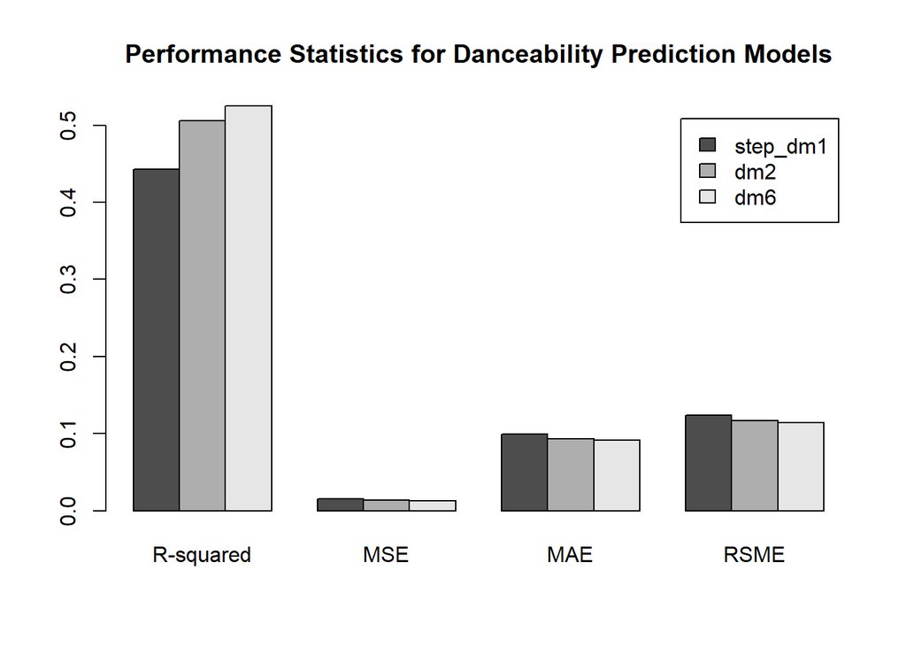

```r
barplot(dm_error_table,legend=T,beside=T,main='Performance Statistics for Danceability Prediction Models')
```

As correlation is improved with subsequent models, the error statistics are reduced correspondingly, signalling that the latter models achieve greater accuracy in their predictions. The greater prediction accuracy confirms that tempo and release year have a significant quadratic effect on Spotify’s danceability score, while energy and valence exhibit slight interactions in the calculation of danceability.

## Danceability Modelling Insights

The Danceability prediction analysis offered some insight into musical elements which Spotify considers to contribute to higher versus lower “danceability.” We summarize them here.

Attributes of More Danceable Music: * loud * cheerful * explicit * speechy * time signature of 4 * moderately high tempo

Attributes of Less Danceable Music: * major key * acoustic * slow or superfast tempo * middle-aged

### Log Model for Hit Classification (mega-hit vs not)

We can start by training a logistic regression model to classify songs as mega-hits vs non-mega-hits.

```r
log_test_labels <- spotify_test$binary_hit_class
log_test <- subset(spotify_test, select=-c(binary_hit_class))
log_train <- subset(spotify_train, select=-c(artists, popularity, year, hit_class, decades))
#log_model <- train(binary_hit_class ~ ., data = log_train, method = "glm", family="binomial")
#summary(log_model)
```

```r
#pred <- predict(log_model, log_test)
#confusionMatrix(pred, log_test_labels)
```

```r
# create function to normalize dataset for KNN
normalize <- function(x){
  return ((x-min(x))/(max(x)-min(x)))
}
```

```r
knn_train <- subset(log_train, select=-c(key))
knn_test <- subset(log_test, select=-c(artists, popularity, year, hit_class, key, decades))
knn_train <- as.data.frame(lapply(knn_train[1:(ncol(knn_train)-1)], normalize))
knn_test <- as.data.frame(lapply(knn_test[1:ncol(knn_test)], normalize))
knn_model_pred <- knn(train=knn_train, test=knn_test, cl=log_train$binary_hit_class, k=95)
```

### Evaluate KNN Model

```r
confusionMatrix(knn_model_pred, log_test_labels)
```

```
## Confusion Matrix and Statistics
##
##           Reference
## Prediction     0     1
##          0 26562  2747
##          1   233   458
##
##                Accuracy : 0.9007
##                  95% CI : (0.8972, 0.904)
##     No Information Rate : 0.8932
##     P-Value [Acc > NIR] : 1.128e-05
##
##                   Kappa : 0.205
##
##  Mcnemar's Test P-Value : < 2.2e-16
##
##             Sensitivity : 0.9913
##             Specificity : 0.1429
##          Pos Pred Value : 0.9063
##          Neg Pred Value : 0.6628
##              Prevalence : 0.8932
##          Detection Rate : 0.8854
##    Detection Prevalence : 0.9770
##       Balanced Accuracy : 0.5671
##
##        'Positive' Class : 0
##
```

## Holding artist constant, what makes a song popular?

The data we have can also be used to predict the popularity of future songs for certain artists. Let us build models to predict which of Taylor Swift’s songs are likely to be popular and also understand what contributes to their popularity. This is important to Taylor Swift’s record label (and her) as popular songs will generate more revenue due to more royalties.

```r
#Selecting Taylor Swift songs
ts_data <- spotify %>% filter(artists =="['Taylor Swift']")
ts_data <- subset(ts_data, select = -c(binary_hit_class, hit_class, decades, artists, year))
ts_data$mode <- as.factor(ts_data$mode)
```

### Linear Regression

First, a linear regression model will give insight into what improves or decreases the popularity of Taylor Swift’s songs.

```r
#Building Linear Regression model
linear_model <- lm(popularity ~ acousticness + energy + explicit + key + liveness + loudness + mode + speechiness, data = ts_data)
summary(linear_model)
```

```
##
## Call:
## lm(formula = popularity ~ acousticness + energy + explicit +
##     key + liveness + loudness + mode + speechiness, data = ts_data)
##
## Residuals:
##     Min      1Q  Median      3Q     Max
## -24.127  -5.876  -1.132   5.929  22.438
##
## Coefficients:
##              Estimate Std. Error t value Pr(>|t|)
## (Intercept)   50.7731     6.2147   8.170 4.24e-14 ***
## acousticness   6.6306     3.2128   2.064  0.04040 *
## energy        14.6978     5.5002   2.672  0.00819 **
## explicit       6.7392     2.7611   2.441  0.01557 *
## key1          -9.7601     3.5854  -2.722  0.00709 **
## key2           0.1150     2.4843   0.046  0.96311
## key3          -1.8247     4.4094  -0.414  0.67947
## key4          -4.5393     2.3678  -1.917  0.05673 .
## key5          -2.9998     2.3042  -1.302  0.19453
## key6          -4.5063     3.9476  -1.142  0.25508
## key7          -1.8427     2.2224  -0.829  0.40807
## key8          -4.7588     3.4379  -1.384  0.16792
## key9           0.6478     2.6858   0.241  0.80968
## key10         -5.3159     3.6361  -1.462  0.14540
## key11         -8.5820     4.2879  -2.001  0.04677 *
## liveness     -15.2887     8.2896  -1.844  0.06669 .
## loudness      -1.2133     0.4338  -2.797  0.00569 **
## mode1         -7.6674     2.7193  -2.820  0.00532 **
## speechiness   42.1068    12.8751   3.270  0.00128 **
## ---
## Signif. codes:  0 '***' 0.001 '**' 0.01 '*' 0.05 '.' 0.1 ' ' 1
##
## Residual standard error: 8.499 on 190 degrees of freedom
## Multiple R-squared:  0.3736, Adjusted R-squared:  0.3142
## F-statistic: 6.295 on 18 and 190 DF,  p-value: 5.27e-12
```

Thus, a record label should make songs that include more of the variables with positive coefficients and reduce the variables that have negative coefficients. For example, it should release a song with more speechiness and acousticness in a minor scale, with less liveness to increase the likelihood of popularity of the song.

### Logistic Regression

A logistic regression model can also be used to gain insight into what makes a Taylor Swift song popular as well as predict the likelihood of popularity of Taylor Swift’s future songs.

```r
str(ts_data)
```

```
## 'data.frame':    209 obs. of  14 variables:
##  $ acousticness    : num  0.111 0.288 0.173 0.575 0.0103 0.17 0.162 0.117 0.00265 0.00478 ...
##  $ danceability    : num  0.668 0.621 0.658 0.58 0.476 0.618 0.687 0.529 0.624 0.543 ...
##  $ duration_ms     : int  201107 203040 173067 232107 242200 235267 231133 293027 230707 265667 ...
##  $ energy          : num  0.672 0.417 0.877 0.491 0.777 0.741 0.783 0.67 0.757 0.818 ...
##  $ explicit        : int  0 0 0 0 0 0 0 0 0 0 ...
##  $ instrumentalness: num  0.00 0.00 0.00 0.00 0.00 0.00 1.35e-05 0.00 1.87e-06 3.68e-04 ...
##  $ key             : Factor w/ 12 levels "0","1","2","3",..: 3 11 8 1 5 3 7 3 8 5 ...
##  $ liveness        : num  0.329 0.119 0.0962 0.121 0.196 0.0822 0.114 0.334 0.189 0.0357 ...
##  $ loudness        : num  -4.93 -6.94 -2.1 -6.46 -3.77 ...
##  $ mode            : Factor w/ 2 levels "0","1": 2 2 2 2 1 2 2 2 2 2 ...
##  $ popularity      : int  66 63 62 61 61 70 69 64 63 63 ...
##  $ speechiness     : num  0.0303 0.0231 0.0323 0.0251 0.0289 0.031 0.0386 0.0303 0.0296 0.0398 ...
##  $ tempo           : num  89 100 106 76 168 ...
##  $ valence         : num  0.539 0.289 0.821 0.425 0.472 0.296 0.443 0.286 0.658 0.683 ...
```

```r
set.seed(12345)
testrows <- sample(1:nrow(ts_data), 0.1*nrow(ts_data))



ts_test <- ts_data[testrows,  ]
ts_train <- ts_data[-testrows,  ]

head(ts_test)
```

```
##     acousticness danceability duration_ms energy explicit instrumentalness key
## 142      0.00364        0.765      247533  0.656        0         8.68e-03   5
## 51       0.07670        0.777      190360  0.658        0         0.00e+00   0
## 152      0.08260        0.436      242080  0.950        0         1.08e-06   5
## 58       0.75700        0.777      210252  0.357        1         7.28e-06   0
## 93       0.09500        0.709      240760  0.599        0         0.00e+00   7
## 75       0.03800        0.793      212600  0.634        0         1.76e-06   7
##     liveness loudness mode popularity speechiness   tempo valence
## 142   0.0918   -6.112    1         56      0.0504 119.997   0.545
## 51    0.0901   -5.191    1         77      0.0540 110.048   0.633
## 152   0.1490   -2.627    1         51      0.0570 162.088   0.352
## 58    0.1080   -6.942    1         79      0.0522 139.883   0.172
## 93    0.0973   -3.734    1         55      0.0304 118.975   0.735
## 75    0.3040   -4.807    1         60      0.0324 117.023   0.615
```

```r
ts_train_labels <- ts_data[-testrows, "popularity"]
ts_test_labels <- ts_data[testrows, "popularity" ]

popularity_threshold_ts <- 50
ts_train$popularity_bin <-ts_train$popularity / 100

ts_train$popularity_bin <- ifelse(ts_train$popularity > popularity_threshold_ts, 1, 0)
ts_test$popularity_bin <- ts_test$popularity / 100

mean(ts_test$popularity_bin)
```

```
## [1] 0.6135
```

```r
ts_test$popularity_bin <- ifelse(ts_test$popularity > popularity_threshold_ts, 1, 0)
summary(as.factor(ts_test$popularity_bin))
```

```
##  0  1
##  2 18
```

```r
ts_train$popularity_bin <- as.factor(ts_train$popularity_bin)
ts_test$popularity_bin <- as.factor(ts_test$popularity_bin)


ts_data$popularity <- NULL
ts_train$popularity <- NULL
ts_test$popularity <- NULL
str(ts_train)
```

```
## 'data.frame':    189 obs. of  14 variables:
##  $ acousticness    : num  0.173 0.575 0.0103 0.17 0.162 0.117 0.00265 0.452 0.0382 0.00454 ...
##  $ danceability    : num  0.658 0.58 0.476 0.618 0.687 0.529 0.624 0.568 0.602 0.622 ...
##  $ duration_ms     : int  173067 232107 242200 235267 231133 293027 230707 237733 327893 217973 ...
##  $ energy          : num  0.877 0.491 0.777 0.741 0.783 0.67 0.757 0.761 0.609 0.469 ...
##  $ explicit        : int  0 0 0 0 0 0 0 0 0 0 ...
##  $ instrumentalness: num  0.00 0.00 0.00 0.00 1.35e-05 0.00 1.87e-06 0.00 2.00e-04 2.25e-06 ...
##  $ key             : Factor w/ 12 levels "0","1","2","3",..: 8 1 5 3 7 3 8 5 1 4 ...
##  $ liveness        : num  0.0962 0.121 0.196 0.0822 0.114 0.334 0.189 0.217 0.127 0.0398 ...
##  $ loudness        : num  -2.1 -6.46 -3.77 -3.95 -4.44 ...
##  $ mode            : Factor w/ 2 levels "0","1": 2 2 1 2 2 2 2 2 2 1 ...
##  $ speechiness     : num  0.0323 0.0251 0.0289 0.031 0.0386 0.0303 0.0296 0.0459 0.0243 0.0363 ...
##  $ tempo           : num  106 76 168 119 130 ...
##  $ valence         : num  0.821 0.425 0.472 0.296 0.443 0.286 0.658 0.789 0.337 0.679 ...
##  $ popularity_bin  : Factor w/ 2 levels "0","1": 2 2 2 2 2 2 2 2 2 2 ...
```

```r
ts_log <- glm(popularity_bin ~ energy +  key + loudness, data = ts_train, family = "binomial")
summary(ts_log)
```

```
##
## Call:
## glm(formula = popularity_bin ~ energy + key + loudness, family = "binomial",
##     data = ts_train)
##
## Deviance Residuals:
##     Min       1Q   Median       3Q      Max
## -2.5083   0.1644   0.4084   0.6567   1.4522
##
## Coefficients:
##              Estimate Std. Error z value Pr(>|z|)
## (Intercept)   -4.1270     2.3401  -1.764 0.077800 .
## energy         5.9331     2.0500   2.894 0.003801 **
## key1          -2.6022     1.3046  -1.995 0.046088 *
## key2          -1.0972     1.2002  -0.914 0.360642
## key3          14.8037  1860.4099   0.008 0.993651
## key4          -0.7476     1.2367  -0.605 0.545474
## key5          -1.5451     1.1644  -1.327 0.184514
## key6          -1.3466     1.4682  -0.917 0.359041
## key7          -1.0493     1.1808  -0.889 0.374189
## key8          -2.0013     1.4531  -1.377 0.168414
## key9          -1.3426     1.2983  -1.034 0.301106
## key10         -2.5467     1.4027  -1.816 0.069441 .
## key11         14.2121  1601.0225   0.009 0.992917
## loudness      -0.5239     0.1569  -3.339 0.000842 ***
## ---
## Signif. codes:  0 '***' 0.001 '**' 0.01 '*' 0.05 '.' 0.1 ' ' 1
##
## (Dispersion parameter for binomial family taken to be 1)
##
##     Null deviance: 171.91  on 188  degrees of freedom
## Residual deviance: 143.06  on 175  degrees of freedom
## AIC: 171.06
##
## Number of Fisher Scoring iterations: 16
```

Taylor Swift’s record label can use this information to produce songs that have a higher degree of energy to increase the likelihood of popularity. They can reduce the loudness of future songs and make songs that do not have C# or A# as the major key to ensure that the future songs are popular.

```r
ts_pred <- predict(ts_log, newdata = ts_test, type = "response")
ts_pred <- ifelse(ts_pred >  popularity_threshold_ts/100, 1, 0)


CrossTable(x = ts_pred, y = ts_test$popularity_bin, prop.chisq=FALSE)
```

```
##
##
##    Cell Contents
## |-------------------------|
## |                       N |
## |           N / Row Total |
## |           N / Col Total |
## |         N / Table Total |
## |-------------------------|
##
##
## Total Observations in Table:  20
##
##
##              | ts_test$popularity_bin
##      ts_pred |         0 |         1 | Row Total |
## -------------|-----------|-----------|-----------|
##            0 |         0 |         1 |         1 |
##              |     0.000 |     1.000 |     0.050 |
##              |     0.000 |     0.056 |           |
##              |     0.000 |     0.050 |           |
## -------------|-----------|-----------|-----------|
##            1 |         2 |        17 |        19 |
##              |     0.105 |     0.895 |     0.950 |
##              |     1.000 |     0.944 |           |
##              |     0.100 |     0.850 |           |
## -------------|-----------|-----------|-----------|
## Column Total |         2 |        18 |        20 |
##              |     0.100 |     0.900 |           |
## -------------|-----------|-----------|-----------|
##
##
```

```r
confusionMatrix(as.factor(ts_test$popularity_bin), as.factor(ts_pred))
```

```
## Confusion Matrix and Statistics
##
##           Reference
## Prediction  0  1
##          0  0  2
##          1  1 17
##
##                Accuracy : 0.85
##                  95% CI : (0.6211, 0.9679)
##     No Information Rate : 0.95
##     P-Value [Acc > NIR] : 0.9841
##
##                   Kappa : -0.0714
##
##  Mcnemar's Test P-Value : 1.0000
##
##             Sensitivity : 0.0000
##             Specificity : 0.8947
##          Pos Pred Value : 0.0000
##          Neg Pred Value : 0.9444
##              Prevalence : 0.0500
##          Detection Rate : 0.0000
##    Detection Prevalence : 0.1000
##       Balanced Accuracy : 0.4474
##
##        'Positive' Class : 0
##
```

Above is the confusion matrix for the predictions of the logistic regression model. The model had an accuracy of 85% and can be used to predict the likelihood of popularity of future Taylor Swift songs.

### Decision Tree

```r
# Build model

ts_train$popularity_bin <- as.factor(ts_train$popularity_bin)
ts_test$popularity_bin <- as.factor(ts_test$popularity_bin)

model <- C5.0(popularity_bin ~ valence + speechiness + liveness + instrumentalness + energy + duration_ms + danceability + acousticness + explicit, data = ts_train)


# Get predictions
test_predictions <- predict(model, newdata = ts_test)
confusionMatrix(as.factor(ts_test$popularity_bin), as.factor(test_predictions))
```

```
## Confusion Matrix and Statistics
##
##           Reference
## Prediction  0  1
##          0  0  2
##          1  0 18
##
##                Accuracy : 0.9
##                  95% CI : (0.683, 0.9877)
##     No Information Rate : 1
##     P-Value [Acc > NIR] : 1.0000
##
##                   Kappa : 0
##
##  Mcnemar's Test P-Value : 0.4795
##
##             Sensitivity :  NA
##             Specificity : 0.9
##          Pos Pred Value :  NA
##          Neg Pred Value :  NA
##              Prevalence : 0.0
##          Detection Rate : 0.0
##    Detection Prevalence : 0.1
##       Balanced Accuracy :  NA
##
##        'Positive' Class : 0
##
```

Above is the confusion matrix for the Decision Tree model. It has an accuracy of 90% and thus this model can be used to better predict the popularity of Taylor Swift’s future songs in comparison to the logistic regression model.

The record label can use the insights gained from the linear regression model and the logistic regression model to tailor the songs to increase the likelihood of popularity. However, since the decision tree model has better accuracy of (90% vs 85%), they can use that model to predict the likelihood of popularity of Taylor Swift’s future songs. Using the models to release songs that are more likely to be popular will increase the royalties (i.e., revenue) generated by the songs.

# Conclusion

Through our analysis of the Spotify dataset, we were able to create many models and predictions that lend themselves to business applications for different stakeholders.

Decades Portion: This section of our report was an interesting dive into the similarities and differences between musical forms throughout the decades. Our model suggests that classifying whether a song is from a particular decade or not is difficult. This makes sense because musical waves can come and go in larger and shorter spans than a decade. When we ran a decision tree model and tried to classify songs into every decade, this hypothesis was substantiated due to the high number of misclassifications into adjacent decades (e.g. 40s and 60s are adjacent to the 50s). Through this decision tree model we were able to see which decades of music were particularly unique because they were classified more easily, and which decades were more free form or transitional decades because of their low accuracy.

Attributes of More Danceable Music:

- loud
- cheerful
- explicit
- speechy
- time signature of 4
- moderately high tempo
- valence with low energy

Attributes of Less Danceable Music:

- major key
- acoustic
- slow or superfast tempo
- middle-aged
- valence with high-energy

Of course, Not all of these correlations ensure causation. For example, major-key music is unlikely to be a determinant of poor danceability. In addition, we discussed in the limitations section that `danceability` score is not necessarily equal to the average listener’s perceived song danceability.

Popularity Prediction portion: Assessing the overall popularity of a song could be a valuable tool for several of the stakeholders listed to begin our report, namely: artists, music producers, and music streaming service providers. An artist or a record label that is aiming to release a single song to build up excitement for an upcoming album might want to pick a song with attributes that are consistent with popular music through the years. Though artists should continue to experiment with music styles and set new trends, this is an example where estimating which songs of an existing album has the best chance to top the music charts and should be released early for promotion could be worthwhile. Finally, assessing widespread popularity is important for streaming providers like Spotify and Apple Music, who benefit from users spending more time listening to music on their apps. Premade playlists meant for large streaming numbers should have a lot of songs that have the potential to become popular, even if they are new or underappreciated before selecting.

Artist portion: The report also builds models to understand what makes a specific artist’s (Taylor Swift’s) songs popular. The models can also be used to predict the popularity of Taylor Swift’s future songs. This is invaluable for Taylor Swift’s record label because they can tailor future songs according to the model’s results to increase the likelihood of popularity and thus potentially increase royalties (revenue).